# Albertos y Marios del Womad

Una pregunta muy importante en ecologia y demografia humana es “**Cual es el nombre mas comun en España dentro de Mario o Alberto?“**. Un grupo de investigacion hicieron un muestreo en el WOMAD Caceres para estimar densidad y abundancia de Marios y Albertos.

## Diseño

El Womad Caceres se representa como una zona de estudio dividida en 100 celdas. Los investigadorxs eligeron 20 celdas de muestro de manera aleatoria para contar los Marios y Albertos.

Un factor possible para describir la densidad de Marios y Albertos puede ser la distancia al bar mas cerca. Hay dos bares en el Womad Cacéres que puedan afectar a las densidades.

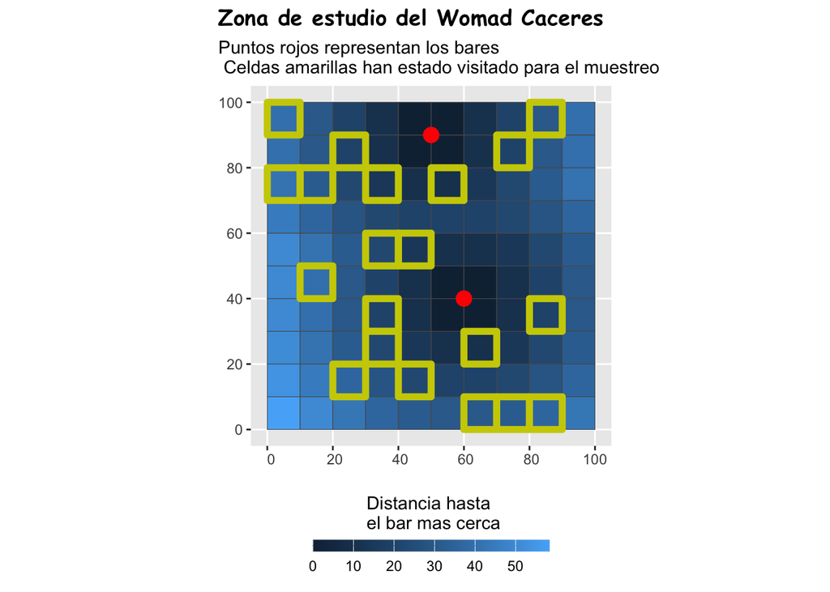

En cada celda, colectaron conteos de Marios `nmarios` y conteos de Albertos `nalbertos`. Podemos ver a los datasets con 20 lineas (una por cada celda), y 3 columnas: `dbar` contiene la distancia de cada celda al bar mas cerca, `dbar.sc` es la distancia `dbar` pero “scaled” (centrada y reducida. Hay que utilizar esta para el modelo y para las prediciones), `nalberto` o `nmario` que contiene el conteo en cada celda.

```r
# load data
load("data_womad.rdata")

nmarios
```

```
       dbar    dbar.sc nmario
70 36.05551  0.7635335      0
56 10.00000 -1.0918099      0
1  58.30952  2.3481817      0
4  36.05551  0.7635335      0
90 40.00000  1.0444099      0
64 22.36068 -0.2116389      0
58 14.14214 -0.7968595      1
69 28.28427  0.2101642      0
32 40.00000  1.0444099      0
57 10.00000 -1.0918099      2
8  31.62278  0.4478902      0
51 50.00000  1.7564831      1
77 14.14214 -0.7968595      0
68 22.36068 -0.2116389      0
40 30.00000  0.3323366      1
45 10.00000 -1.0918099      0
96  0.00000 -1.8038831      0
42 40.00000  1.0444099      1
6  30.00000  0.3323366      0
31 50.00000  1.7564831      1
```

```r
nalbertos
```

```
       dbar    dbar.sc nalberto
9  36.05551  0.7635335        0
74 14.14214 -0.7968595        0
76 10.00000 -1.0918099        3
55 14.14214 -0.7968595        1
72 31.62278  0.4478902        1
54 22.36068 -0.2116389        0
39 20.00000 -0.3797366        1
83 20.00000 -0.3797366        0
88 20.00000 -0.3797366        1
15 22.36068 -0.2116389        0
91 40.00000  1.0444099        0
42 40.00000  1.0444099        0
71 41.23106  1.1320701        0
99 30.00000  0.3323366        0
34 20.00000 -0.3797366        0
24 22.36068 -0.2116389        0
13 36.05551  0.7635335        0
8  31.62278  0.4478902        1
7  30.00000  0.3323366        1
27 10.00000 -1.0918099        2
```

## Pregunta de modelizacion

**Con un GLM, modelizais la densidad y abundancia de Marios y Albertos en el Womad Caceres como funcion de la distancia al bar mas cerca.**

**Que podeis concluir?**

**SPOILER BELOW**

$$~~$$
$$~~$$
$$~~$$

## Modelo

### Equaciones

Vamos a construir un GLM para modelizar los conteos como funcion de la distancia al bar mas cerca en cada celda $i$.

Para los Marios:

$$N^{mario}_i ~ \mbox{Poisson}(\lambda_i)$$

$$\mbox{log}(\lambda_i) = m_0 + m_1 \mbox{Distancia al bar}_i$$
Para los Albertos:

$$N^{albertos}_i ~ \mbox{Poisson}(\lambda_i)$$

$$\mbox{log}(\lambda_i) = a_0 + a_1 \mbox{Distancia al bar}_i$$
Y nosotros queriamos estimar $a_0$, $a_1$, $m_0$, y $m_1$.

### Codigo Nimble

```r
library(nimble)

mariosyalbertos <- nimbleCode({

  # priors
  m0 ~ dnorm(0,1)
  m1 ~ dnorm(0,1)
  a0 ~ dnorm(0,1)
  a1 ~ dnorm(0,1)

  # likelihood
  for(i in 1:nsites){

    # lambda
    log(lamario[i]) <-  m0 + m1 * distToBar[i]
    log(lalberto[i]) <-  a0 + a1 * distToBar[i]


    marios[i] ~ dpois(lamario[i])
    albertos[i]  ~ dpois(lalberto[i])

  }

})
```

### Entrar los datos.

```r
data <- list(marios = nmarios$nmario,
             albertos = nalbertos$nalberto)

constants <- list(nsites = length(nsamp),
                  distToBar = nmarios$dbar.sc)

# initial values
inits <- list(m0 = 1,
              m1 = 0,
              a0 = 1,
              a1 = 0)
```

### Correr el modelo

```r
# lets run Nimble
samples <- nimbleMCMC(code = mariosyalbertos,
                      data = data,
                      constants = constants,
                      inits = inits,
                      monitors =  c("a0", "a1", "m0", "m1"),
                      niter = 1000,
                      nburnin = 100,
                      nchains = 2)
```

```
|-------------|-------------|-------------|-------------|
|-------------------------------------------------------|
|-------------|-------------|-------------|-------------|
|-------------------------------------------------------|
```

### Checkear la convergencia

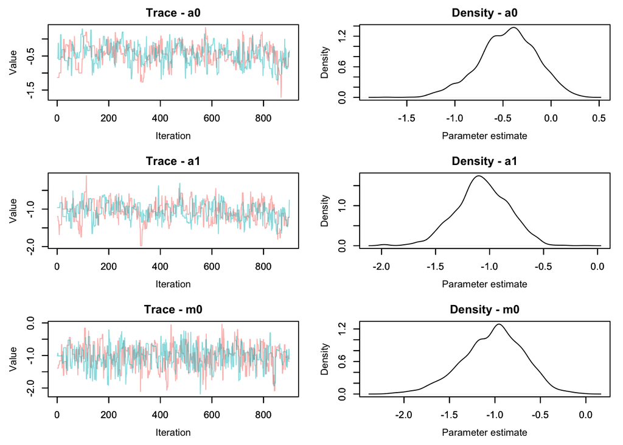

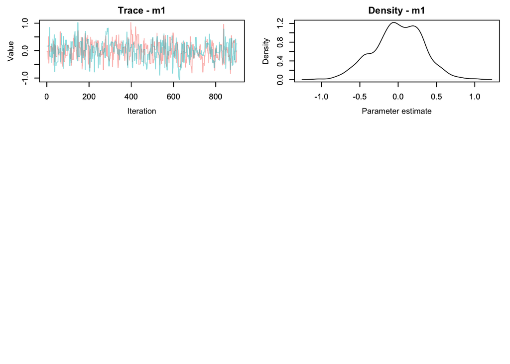

```r
# check convergence
library(MCMCvis)

MCMCtrace(samples, pdf = F)
```

```r
MCMCsummary(samples, round =2)
```

```
    mean   sd  2.5%   50% 97.5% Rhat n.eff
a0 -0.45 0.30 -1.06 -0.44  0.10 1.02   175
a1 -1.07 0.24 -1.54 -1.07 -0.60 1.02   199
m0 -1.02 0.34 -1.74 -0.99 -0.42 1.00   443
m1  0.00 0.33 -0.65  0.01  0.60 1.00   379
```

```r
str(samples)
```

```
List of 2
 $ chain1: num [1:900, 1:4] -1.13 -1.13 -1.13 -1.13 -1.13 ...
  ..- attr(*, "dimnames")=List of 2
  .. ..$ : NULL
  .. ..$ : chr [1:4] "a0" "a1" "m0" "m1"
 $ chain2: num [1:900, 1:4] -0.565 -0.565 -0.565 -0.126 -0.126 ...
  ..- attr(*, "dimnames")=List of 2
  .. ..$ : NULL
  .. ..$ : chr [1:4] "a0" "a1" "m0" "m1"
```

### Prediccion

“*Propagando la incertitumbre*”.

Por cada iteracion, vamos a predecir la densidad de Marios y Albertos en cada celda del WOMAD Cacéres. **Ciudado: hemos centrado y reducido la variable “Distancia hasta el bar”.** Entonces, hay que hacer las predicciones con la variable centrada-reducida `dbar.sc`.

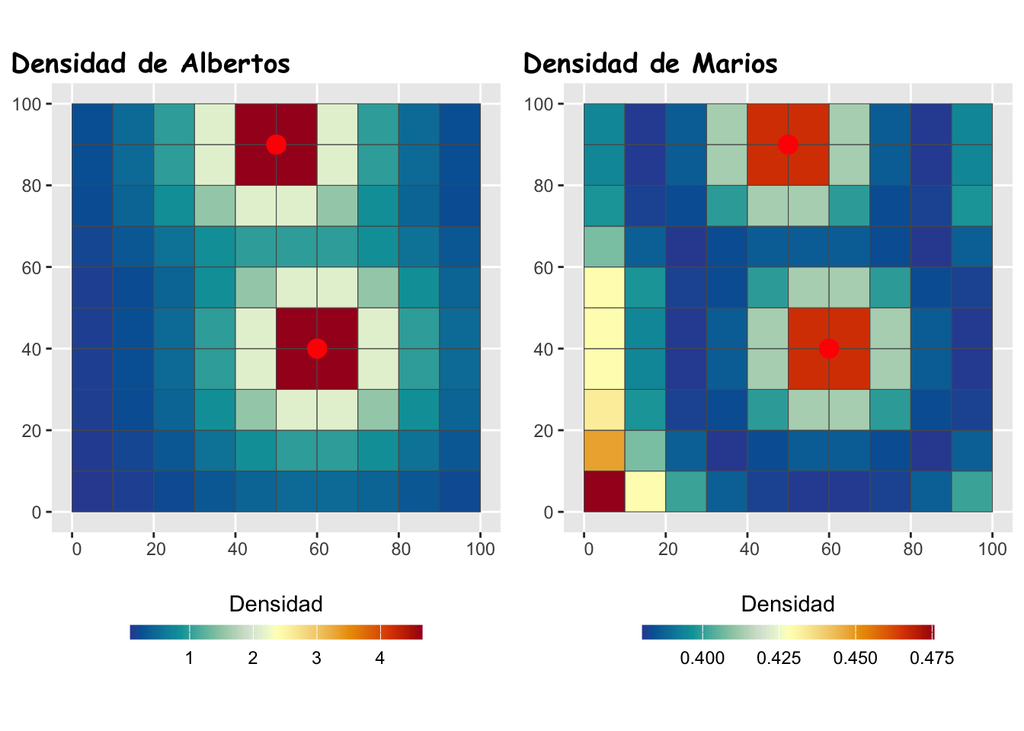

```r
# juntar las dos cadenas
samplesbind <- rbind(samples$chain1, samples$chain2)

# extraer la valores para predecir
pred.dbar <- ggrid$dbar.sc

# preallocate memory
pred.alberto <- pred.mario <- matrix(NA, nrow = nrow(samplesbind), ncol = length(pred.dbar))

# por cada iteracion i
for(i in 1:nrow(pred.alberto)){

  # predecimos la densidad lambda en cada celda pred.bar
  pred.alberto[i,] <- exp(samplesbind[i,"a0"] + samplesbind[i,"a1"] * pred.dbar)
  pred.mario[i,]<- exp(samplesbind[i,"m0"] + samplesbind[i,"m1"] * pred.dbar)

}

# calculamos la media de cada celda por cada iteracion
palberto <- apply(pred.alberto,2,mean)
pmario <- apply(pred.mario,2,mean)


# Calculamos el tamano de poblacion de Marios y Albertos sumando la densidad de todas las celdas
Nmar <- sum(pmario)
Nalb <- sum(palberto)

# Plot of density maps of Marios and Albertos
plot_alb <- ggplot() + geom_sf(data = ggrid, aes(fill = palberto))+
  geom_sf(data = bar, size = 4, color = 'red')+
   labs(title = "Densidad de Albertos",
       fill = "Densidad") +
  theme(plot.title = element_text(family = "Comic Sans MS", face = "bold", color = "black"),
        legend.position = "bottom",
        plot.title.position = "plot") +
  paletteer::scale_fill_paletteer_c(palette = "grDevices::RdYlBu", direction = -1)+
    guides(fill = guide_colourbar(title.position = 'top', title.hjust = .5,
                                barwidth = unit(10, 'lines'), barheight = unit(.5, 'lines')),
         colour = "none")

plot_mar <- ggplot() + geom_sf(data = ggrid, aes(fill = pmario)) +
  geom_sf(data = bar, size = 4, color = 'red') +
   labs(title = "Densidad de Marios",
       fill = "Densidad") +
  theme(plot.title = element_text(family = "Comic Sans MS", face = "bold", color = "black"),
        legend.position = "bottom",
        plot.title.position = "plot") +
  paletteer::scale_fill_paletteer_c(palette = "grDevices::RdYlBu", direction = -1)+
    guides(fill = guide_colourbar(title.position = 'top', title.hjust = .5,
                                barwidth = unit(10, 'lines'), barheight = unit(.5, 'lines')),
         colour = "none")

library(cowplot)

plot_grid(plot_alb, plot_mar)
```

El tamaño de poblacion:

- De los Marios

```r
Nmar
```

```
[1] 40.11024
```

- De los Albertos

```r
Nalb
```

```
[1] 112.9311
```

## Discusion

Resultados muy de acuerdo con la [literatura cientifica actual](https://www.saberespractico.com/curiosidades/nombres-de-hombre-mas-comunes-en-espana/) y con conocimientos proprios de los investigarxs sobre Alberto y los bares.

Fin.